# Regressão: Técnicas de seleção

Ana Cristina Braga

terça-feira, 15 de outubro de 2024

## Técnicas de seleção stepwise (exemplos)

```r
# packages a instalar

# install.packages("tidyverse")
# install.packages("caret")
# install.packages("leaps")
#install.packages("DT")

library(tidyverse)
library(caret)
library(leaps)
library(DT)

library(MASS)
datatable(swiss)
```

|  | Fertility | Agriculture | Examination | Education | Catholic | Infant.Mortality |
| --- | --- | --- | --- | --- | --- | --- |
| Courtelary | 80.2 | 17 | 15 | 12 | 9.96 | 22.2 |
| Delemont | 83.1 | 45.1 | 6 | 9 | 84.84 | 22.2 |
| Franches-Mnt | 92.5 | 39.7 | 5 | 5 | 93.4 | 20.2 |
| Moutier | 85.8 | 36.5 | 12 | 7 | 33.77 | 20.3 |
| Neuveville | 76.9 | 43.5 | 17 | 15 | 5.16 | 20.6 |
| Porrentruy | 76.1 | 35.3 | 9 | 7 | 90.57 | 26.6 |
| Broye | 83.8 | 70.2 | 16 | 7 | 92.85 | 23.6 |
| Glane | 92.4 | 67.8 | 14 | 8 | 97.16 | 24.9 |
| Gruyere | 82.4 | 53.3 | 12 | 7 | 97.67 | 21 |
| Sarine | 82.9 | 45.2 | 16 | 13 | 91.38 | 24.4 |

[output cut: 37 more lines]

```r
#swiss %>%
#  head() %>%
 # DT::datatable()
#head(swiss)
```

## Descrição das variáveis do dataset “swiss”

O dataset *swiss* disponível no R, com 47 observações em 6 variáveis, cada uma delas em percentagem, ou seja, em [0, 100].

Assim:

- **[, 1] Fertility** - Ig, ‘medida de fertilidade padronizada comum’
- **[, 2] Agriculture** - % de homens envolvidos na agricultura como ocupação
- **[, 3] Examination** -% recrutados recebendo nota mais alta no exame do exército
- **[, 4] Education** -% educação além da escola primária para recrutados.
- **[, 5] Catholic** -% ‘católico’ (em oposição a ‘protestante’).
- **[, 6] Infant.Mortality** - nascidos vivos que vivem menos de 1 ano.

Todas as variáveis, exceto “Fertilidade” fornecem proporções relativas da população.

## Matriz de correlação entre variáveis quantitativas

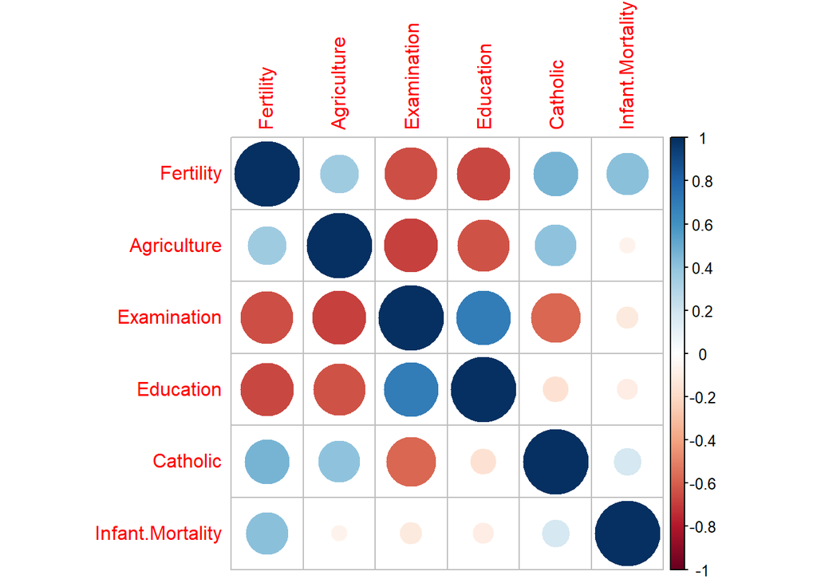

```r
#install.packages("corrplot")
library(corrplot)
M <- cor(swiss)
corrplot(M, method = "circle")
```

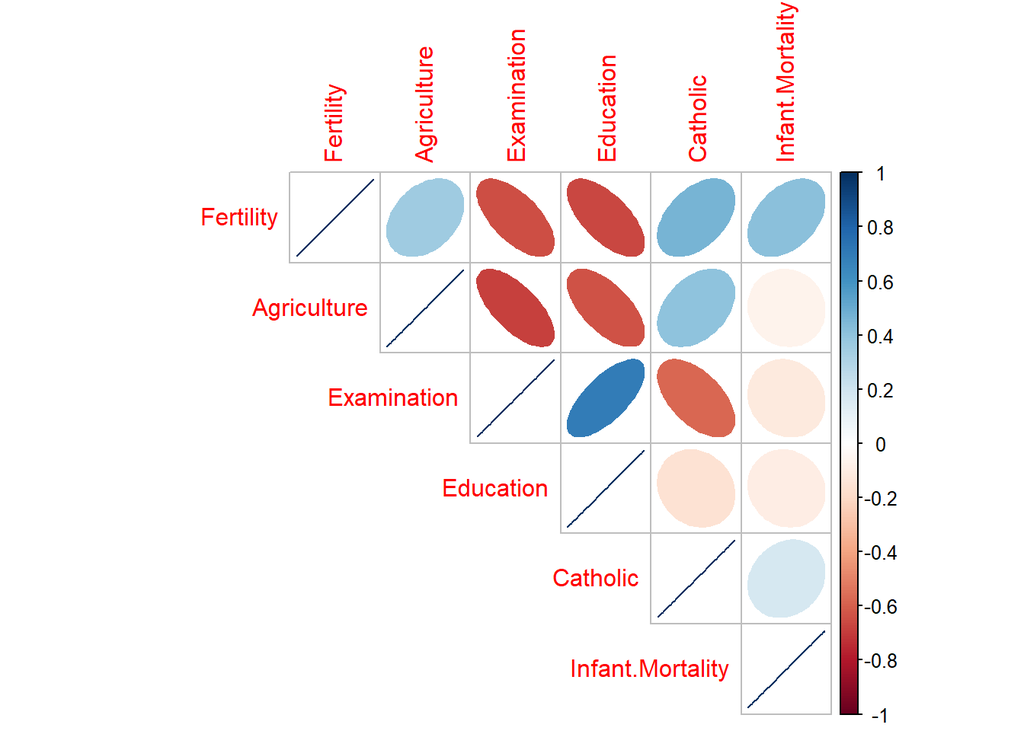

```r
corrplot(M, method = "ellipse", type = "upper")
```

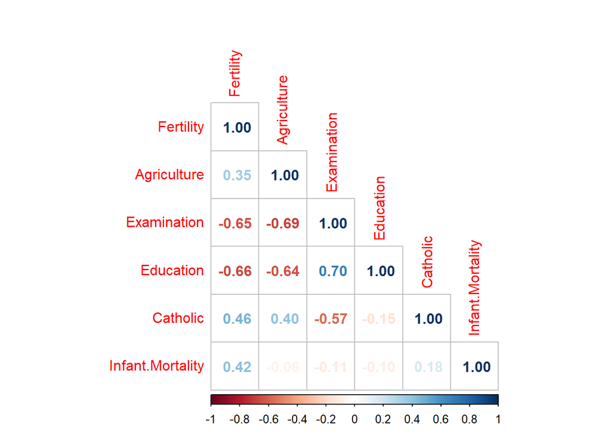

```r
corrplot(M, method = "number", type = "lower")
```

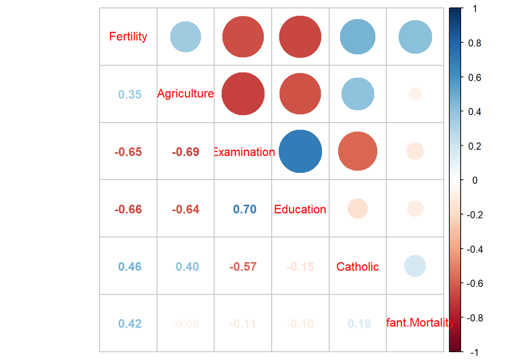

```r
corrplot.mixed(M)
```

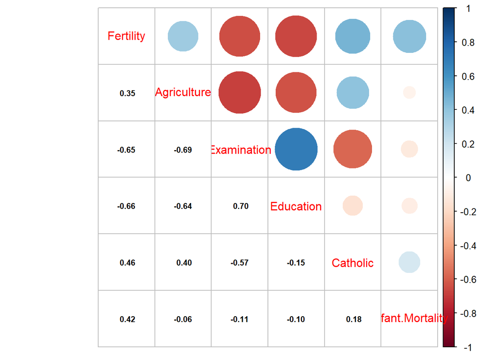

```r
corrplot.mixed(M,lower.col = "black", number.cex = .7)
```

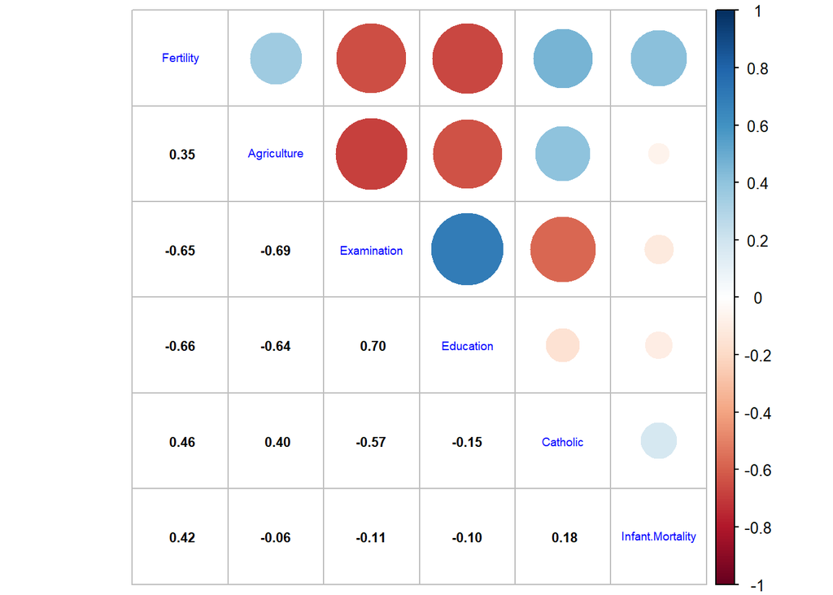

```r
corrplot.mixed(M,lower.col = "black", number.cex = .7, tl.col = "blue", tl.cex = .6)
```

## Exemplo de ajustes de modelos de regressão

```r
# Ajuste completo do modelo

full.model <- lm(Fertility ~., data = swiss)
summary(full.model)
```

```
##
## Call:
## lm(formula = Fertility ~ ., data = swiss)
##
## Residuals:
##      Min       1Q   Median       3Q      Max
## -15.2743  -5.2617   0.5032   4.1198  15.3213
##
## Coefficients:
##                  Estimate Std. Error t value Pr(>|t|)
## (Intercept)      66.91518   10.70604   6.250 1.91e-07 ***
## Agriculture      -0.17211    0.07030  -2.448  0.01873 *
## Examination      -0.25801    0.25388  -1.016  0.31546
## Education        -0.87094    0.18303  -4.758 2.43e-05 ***
## Catholic          0.10412    0.03526   2.953  0.00519 **
## Infant.Mortality  1.07705    0.38172   2.822  0.00734 **
## ---
## Signif. codes:  0 '***' 0.001 '**' 0.01 '*' 0.05 '.' 0.1 ' ' 1
##
## Residual standard error: 7.165 on 41 degrees of freedom
## Multiple R-squared:  0.7067, Adjusted R-squared:  0.671
## F-statistic: 19.76 on 5 and 41 DF,  p-value: 5.594e-10
```

```r
# modelo de regressão utilizando Stepwise
# stepAIC(object, scope, scale = 0,
#         direction = c("both", "backward", "forward"),
#         trace = 1, keep = NULL, steps = 1000, use.start = FALSE,
#         k = 2, ...)

step.model <- stepAIC(full.model, direction = "both",
                      trace = FALSE)
summary(step.model)
```

```
##
## Call:
## lm(formula = Fertility ~ Agriculture + Education + Catholic +
##     Infant.Mortality, data = swiss)
##
## Residuals:
##      Min       1Q   Median       3Q      Max
## -14.6765  -6.0522   0.7514   3.1664  16.1422
##
## Coefficients:
##                  Estimate Std. Error t value Pr(>|t|)
## (Intercept)      62.10131    9.60489   6.466 8.49e-08 ***
## Agriculture      -0.15462    0.06819  -2.267  0.02857 *
## Education        -0.98026    0.14814  -6.617 5.14e-08 ***
## Catholic          0.12467    0.02889   4.315 9.50e-05 ***
## Infant.Mortality  1.07844    0.38187   2.824  0.00722 **
## ---
## Signif. codes:  0 '***' 0.001 '**' 0.01 '*' 0.05 '.' 0.1 ' ' 1
##
## Residual standard error: 7.168 on 42 degrees of freedom
## Multiple R-squared:  0.6993, Adjusted R-squared:  0.6707
## F-statistic: 24.42 on 4 and 42 DF,  p-value: 1.717e-10
```

```r
step.modelb <- stepAIC(full.model, direction = "backward",
                      trace = FALSE)
summary(step.modelb)
```

```
##
## Call:
## lm(formula = Fertility ~ Agriculture + Education + Catholic +
##     Infant.Mortality, data = swiss)
##
## Residuals:
##      Min       1Q   Median       3Q      Max
## -14.6765  -6.0522   0.7514   3.1664  16.1422
##
## Coefficients:
##                  Estimate Std. Error t value Pr(>|t|)
## (Intercept)      62.10131    9.60489   6.466 8.49e-08 ***
## Agriculture      -0.15462    0.06819  -2.267  0.02857 *
## Education        -0.98026    0.14814  -6.617 5.14e-08 ***
## Catholic          0.12467    0.02889   4.315 9.50e-05 ***
## Infant.Mortality  1.07844    0.38187   2.824  0.00722 **
## ---
## Signif. codes:  0 '***' 0.001 '**' 0.01 '*' 0.05 '.' 0.1 ' ' 1
##
## Residual standard error: 7.168 on 42 degrees of freedom
## Multiple R-squared:  0.6993, Adjusted R-squared:  0.6707
## F-statistic: 24.42 on 4 and 42 DF,  p-value: 1.717e-10
```

```r
step.modelf <- stepAIC(full.model, direction = "forward",
                       trace = FALSE)
summary(step.modelf)
```

```
##
## Call:
## lm(formula = Fertility ~ Agriculture + Examination + Education +
##     Catholic + Infant.Mortality, data = swiss)
##
## Residuals:
##      Min       1Q   Median       3Q      Max
## -15.2743  -5.2617   0.5032   4.1198  15.3213
##
## Coefficients:
##                  Estimate Std. Error t value Pr(>|t|)
## (Intercept)      66.91518   10.70604   6.250 1.91e-07 ***
## Agriculture      -0.17211    0.07030  -2.448  0.01873 *
## Examination      -0.25801    0.25388  -1.016  0.31546
## Education        -0.87094    0.18303  -4.758 2.43e-05 ***
## Catholic          0.10412    0.03526   2.953  0.00519 **
## Infant.Mortality  1.07705    0.38172   2.822  0.00734 **
## ---
## Signif. codes:  0 '***' 0.001 '**' 0.01 '*' 0.05 '.' 0.1 ' ' 1
##
## Residual standard error: 7.165 on 41 degrees of freedom
## Multiple R-squared:  0.7067, Adjusted R-squared:  0.671
## F-statistic: 19.76 on 5 and 41 DF,  p-value: 5.594e-10
```

```r
# Set seed for reproducibility
set.seed(123)
# Set up repeated k-fold cross-validation
train.control <- trainControl(method = "cv", number = 10)
# Train the model
step.model_t <- train(Fertility ~., data = swiss,
                    method = "leapBackward",
                    tuneGrid = data.frame(nvmax = 1:5),
                    trControl = train.control
)
step.model_t$results
```

```
##   nvmax     RMSE  Rsquared      MAE   RMSESD RsquaredSD    MAESD
## 1     1 9.227550 0.4366973 7.857870 1.777707  0.3218266 1.939873
## 2     2 8.710164 0.4781831 7.513855 1.660346  0.2653541 1.644553
## 3     3 8.085123 0.6207448 7.038078 2.616606  0.2398241 2.785069
## 4     4 7.376207 0.6699474 6.282399 2.646797  0.2724446 2.671684
## 5     5 7.424916 0.6922072 6.312180 2.891761  0.2722295 2.828701
```

```r
step.model_t$bestTune
```

```
##   nvmax
## 4     4
```

```r
summary(step.model_t$finalModel)
```

```
## Subset selection object
## 5 Variables  (and intercept)
##                  Forced in Forced out
## Agriculture          FALSE      FALSE
## Examination          FALSE      FALSE
## Education            FALSE      FALSE
## Catholic             FALSE      FALSE
## Infant.Mortality     FALSE      FALSE
## 1 subsets of each size up to 4
## Selection Algorithm: backward
##          Agriculture Examination Education Catholic Infant.Mortality
## 1  ( 1 ) " "         " "         "*"       " "      " "
## 2  ( 1 ) " "         " "         "*"       "*"      " "
## 3  ( 1 ) " "         " "         "*"       "*"      "*"
## 4  ( 1 ) "*"         " "         "*"       "*"      "*"
```

```r
coef(step.model_t$finalModel, 4)
```

```
##      (Intercept)      Agriculture        Education         Catholic
##       62.1013116       -0.1546175       -0.9802638        0.1246664
## Infant.Mortality
##        1.0784422
```

```r
#ou
lm(Fertility ~ Agriculture + Education + Catholic + Infant.Mortality,
   data = swiss)
```

```
##
## Call:
## lm(formula = Fertility ~ Agriculture + Education + Catholic +
##     Infant.Mortality, data = swiss)
##
## Coefficients:
##      (Intercept)       Agriculture         Education          Catholic
##          62.1013           -0.1546           -0.9803            0.1247
## Infant.Mortality
##           1.0784
```

```r
AIC(step.model)
```

```
## [1] 325.2408
```

```r
AIC(step.modelb)
```

```
## [1] 325.2408
```

```r
AIC(step.modelf)
```

```
## [1] 326.0716
```

## Regressão com covariáveis

```r
#' hsb2: High School and Beyond Data Set
hsb2 <- read.csv("https://stats.idre.ucla.edu/stat/data/hsb2.csv")
#' ou no package blorr
#install.packages("blorr")
#library(blorr)

datatable(hsb2)
```

|  | id | female | race | ses | schtyp | prog | read | write | math | science | socst |
| --- | --- | --- | --- | --- | --- | --- | --- | --- | --- | --- | --- |
| 1 | 70 | 0 | 4 | 1 | 1 | 1 | 57 | 52 | 41 | 47 | 57 |
| 2 | 121 | 1 | 4 | 2 | 1 | 3 | 68 | 59 | 53 | 63 | 61 |
| 3 | 86 | 0 | 4 | 3 | 1 | 1 | 44 | 33 | 54 | 58 | 31 |
| 4 | 141 | 0 | 4 | 3 | 1 | 3 | 63 | 44 | 47 | 53 | 56 |
| 5 | 172 | 0 | 4 | 2 | 1 | 2 | 47 | 52 | 57 | 53 | 61 |
| 6 | 113 | 0 | 4 | 2 | 1 | 2 | 44 | 52 | 51 | 63 | 61 |
| 7 | 50 | 0 | 3 | 2 | 1 | 1 | 50 | 59 | 42 | 53 | 61 |
| 8 | 11 | 0 | 1 | 2 | 1 | 2 | 34 | 46 | 45 | 39 | 36 |
| 9 | 84 | 0 | 4 | 2 | 1 | 1 | 63 | 57 | 54 | 58 | 51 |
| 10 | 48 | 0 | 3 | 2 | 1 | 2 | 57 | 55 | 52 | 50 | 51 |

[output cut: 190 more lines]

- **id** - Student ID.
- **gender** - Student’s gender, with levels female and male.
- **race** - Student’s race, with levels african american, asian, hispanic, and white.
- **ses** - Socio economic status of student’s family, with levels low, middle, and high.
- **schtyp** - Type of school, with levels public and private.
- **prog** -Type of program, with levels general, academic, and vocational.
- **read**- Standardized reading score.
- **write** - Standardized writing score.
- **math** - Standardized math score.
- **science** - Standardized science score.
- **socst** - Standardized social studies score.

```r
#head(hsb2)
#' criação de uma variável como factor

hsb2$female.f<- factor(hsb2$female)
hsb2$race.f <- factor(hsb2$race )

levels(hsb2$female.f)<-c("M","F")
levels(hsb2$race.f)<-c("african","asian","hispanic","white")

is.factor(hsb2$race.f)
```

```
## [1] TRUE
```

```r
tabulate(hsb2$race.f)
```

```
## [1]  24  11  20 145
```

```r
tabulate(hsb2$female.f)
```

```
## [1]  91 109
```

```r
hsb2$race.f[1:15]
```

```
##  [1] white    white    white    white    white    white    hispanic african
##  [9] white    hispanic white    white    white    white    hispanic
## Levels: african asian hispanic white
```

```r
attach(hsb2)

summary(race)
```

```
##    Min. 1st Qu.  Median    Mean 3rd Qu.    Max.
##    1.00    3.00    4.00    3.43    4.00    4.00
```

```r
summary(race.f)
```

```
##  african    asian hispanic    white
##       24       11       20      145
```

```r
summary(female.f)
```

```
##   M   F
##  91 109
```

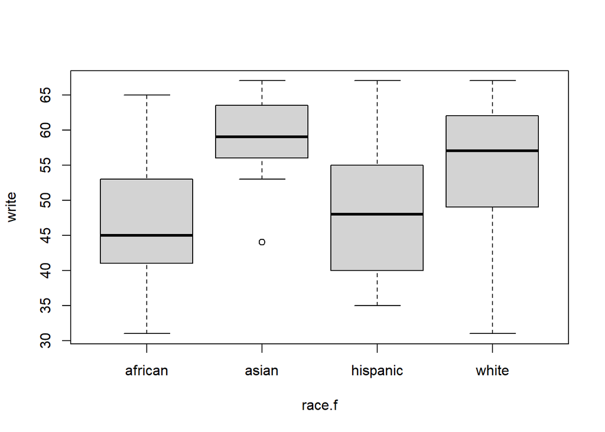

```r
boxplot(write~race.f)
```

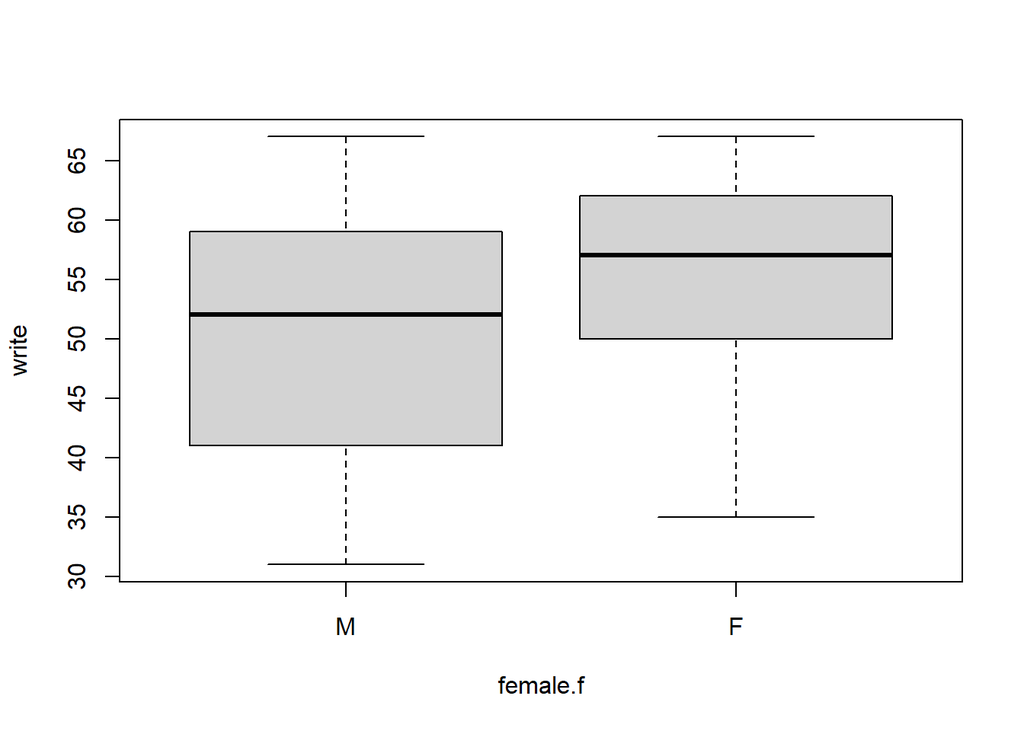

```r
boxplot(write~female.f)
```

```r
#'considerando a variável "write" como dependente

yhat=lm(write ~ race.f, data = hsb2)
summary(yhat)
```

```
##
## Call:
## lm(formula = write ~ race.f, data = hsb2)
##
## Residuals:
##      Min       1Q   Median       3Q      Max
## -23.0552  -5.4583   0.9724   7.0000  18.8000
##
## Coefficients:
##                Estimate Std. Error t value Pr(>|t|)
## (Intercept)      46.458      1.842  25.218  < 2e-16 ***
## race.fasian      11.542      3.286   3.512 0.000552 ***
## race.fhispanic    1.742      2.732   0.637 0.524613
## race.fwhite       7.597      1.989   3.820 0.000179 ***
## ---
## Signif. codes:  0 '***' 0.001 '**' 0.01 '*' 0.05 '.' 0.1 ' ' 1
##
## Residual standard error: 9.025 on 196 degrees of freedom
## Multiple R-squared:  0.1071, Adjusted R-squared:  0.0934
## F-statistic: 7.833 on 3 and 196 DF,  p-value: 5.785e-05
```

```r
#'ou em alternativa
yhat_alt=lm(write ~ factor(race), data = hsb2)
summary(yhat_alt)
```

```
##
## Call:
## lm(formula = write ~ factor(race), data = hsb2)
##
## Residuals:
##      Min       1Q   Median       3Q      Max
## -23.0552  -5.4583   0.9724   7.0000  18.8000
##
## Coefficients:
##               Estimate Std. Error t value Pr(>|t|)
## (Intercept)     46.458      1.842  25.218  < 2e-16 ***
## factor(race)2   11.542      3.286   3.512 0.000552 ***
## factor(race)3    1.742      2.732   0.637 0.524613
## factor(race)4    7.597      1.989   3.820 0.000179 ***
## ---
## Signif. codes:  0 '***' 0.001 '**' 0.01 '*' 0.05 '.' 0.1 ' ' 1
##
## Residual standard error: 9.025 on 196 degrees of freedom
## Multiple R-squared:  0.1071, Adjusted R-squared:  0.0934
## F-statistic: 7.833 on 3 and 196 DF,  p-value: 5.785e-05
```

```r
summary(lm(write ~ race, data = hsb2))
```

```
##
## Call:
## lm(formula = write ~ race, data = hsb2)
##
## Residuals:
##     Min      1Q  Median      3Q     Max
## -22.919  -5.912   1.091   8.082  17.100
##
## Coefficients:
##             Estimate Std. Error t value Pr(>|t|)
## (Intercept)  45.8941     2.2652  20.260  < 2e-16 ***
## race          2.0061     0.6322   3.173  0.00175 **
## ---
## Signif. codes:  0 '***' 0.001 '**' 0.01 '*' 0.05 '.' 0.1 ' ' 1
##
## Residual standard error: 9.27 on 198 degrees of freedom
## Multiple R-squared:  0.0484, Adjusted R-squared:  0.04359
## F-statistic: 10.07 on 1 and 198 DF,  p-value: 0.001747
```

```r
hsb2W=hsb2[c(2:6,8)]

yhat_g=lm(write~factor(race)+factor(female)+factor(ses)+factor(schtyp)+factor(prog),data = hsb2)
summary(yhat_g)
```

```
##
## Call:
## lm(formula = write ~ factor(race) + factor(female) + factor(ses) +
##     factor(schtyp) + factor(prog), data = hsb2)
##
## Residuals:
##      Min       1Q   Median       3Q      Max
## -22.6159  -4.6932   0.3381   5.4092  17.8269
##
## Coefficients:
##                 Estimate Std. Error t value Pr(>|t|)
## (Intercept)      42.8257     2.1935  19.524  < 2e-16 ***
## factor(race)2     8.5033     2.9529   2.880  0.00444 **
## factor(race)3     0.7350     2.4325   0.302  0.76286
## factor(race)4     5.8334     1.7984   3.244  0.00139 **
## factor(female)1   4.8436     1.1539   4.198 4.14e-05 ***
## factor(ses)2      0.8390     1.5211   0.552  0.58188
## factor(ses)3      2.6094     1.6926   1.542  0.12482
## factor(schtyp)2   0.3295     1.6033   0.206  0.83738
## factor(prog)2     4.3475     1.4596   2.978  0.00328 **
## factor(prog)3    -3.8049     1.6780  -2.267  0.02449 *
## ---
## Signif. codes:  0 '***' 0.001 '**' 0.01 '*' 0.05 '.' 0.1 ' ' 1
##
## Residual standard error: 7.959 on 190 degrees of freedom
## Multiple R-squared:  0.3269, Adjusted R-squared:  0.295
## F-statistic: 10.25 on 9 and 190 DF,  p-value: 7.825e-13
```

```r
library(tidyverse)
library(caret)
library(leaps)

library(MASS)

step.model <- stepAIC(yhat_g, direction = "both",
                      trace = FALSE)
summary(step.model)
```

```
##
## Call:
## lm(formula = write ~ factor(race) + factor(female) + factor(prog),
##     data = hsb2)
##
## Residuals:
##     Min      1Q  Median      3Q     Max
## -21.695  -5.346   0.102   5.654  17.029
##
## Coefficients:
##                 Estimate Std. Error t value Pr(>|t|)
## (Intercept)      43.5229     2.0437  21.296  < 2e-16 ***
## factor(race)2     8.7846     2.9410   2.987 0.003183 **
## factor(race)3     0.6051     2.4219   0.250 0.802961
## factor(race)4     6.3024     1.7646   3.572 0.000448 ***
## factor(female)1   4.6512     1.1389   4.084 6.49e-05 ***
## factor(prog)2     4.8694     1.4209   3.427 0.000746 ***
## factor(prog)3    -3.8085     1.6502  -2.308 0.022062 *
## ---
## Signif. codes:  0 '***' 0.001 '**' 0.01 '*' 0.05 '.' 0.1 ' ' 1
##
## Residual standard error: 7.954 on 193 degrees of freedom
## Multiple R-squared:  0.3171, Adjusted R-squared:  0.2958
## F-statistic: 14.93 on 6 and 193 DF,  p-value: 5.263e-14
```

```r
coef(step.model)
```

```
##     (Intercept)   factor(race)2   factor(race)3   factor(race)4 factor(female)1
##      43.5229133       8.7845878       0.6051232       6.3023598       4.6512258
##   factor(prog)2   factor(prog)3
##       4.8693614      -3.8084865
```

```r
summary(residuals(step.model))
```

```
##    Min. 1st Qu.  Median    Mean 3rd Qu.    Max.
## -21.695  -5.346   0.102   0.000   5.654  17.029
```

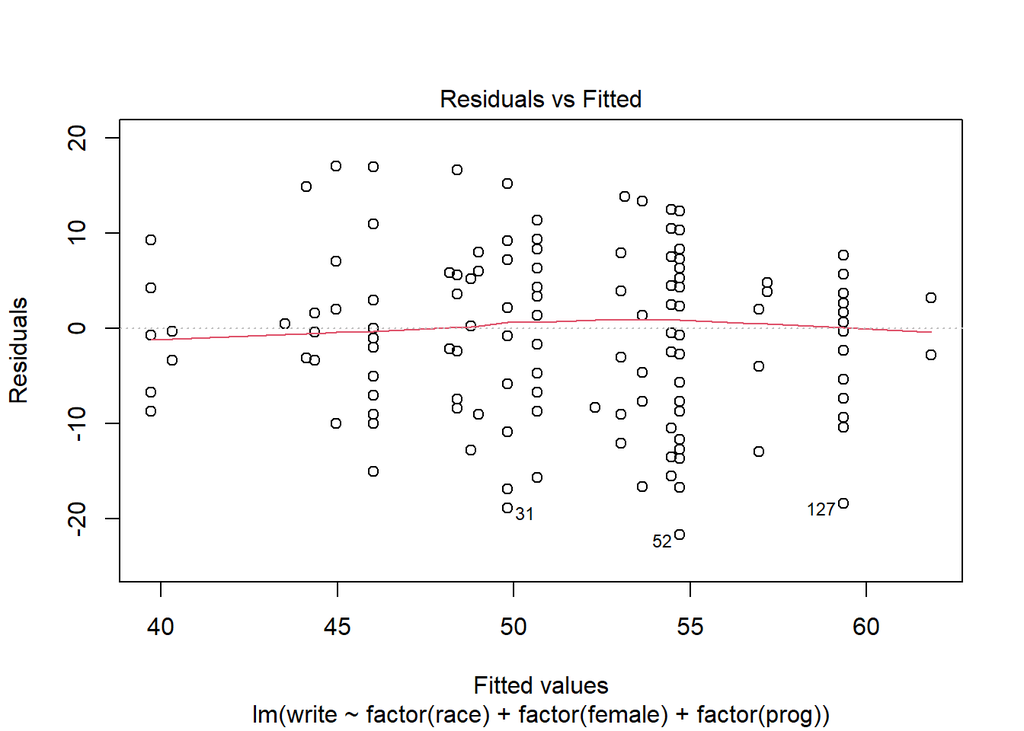

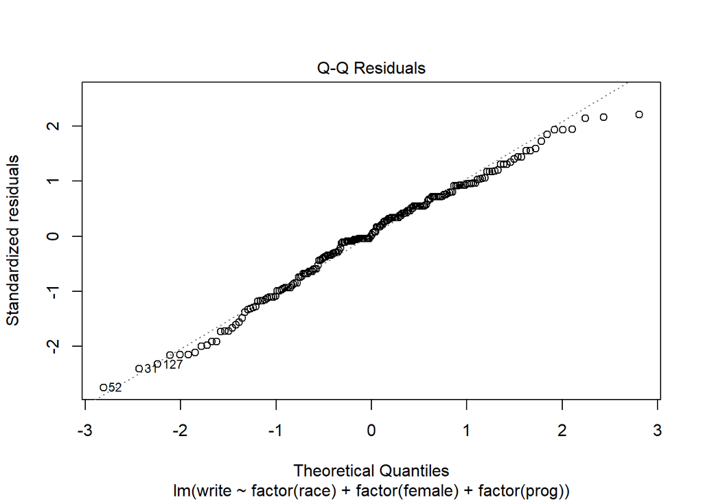

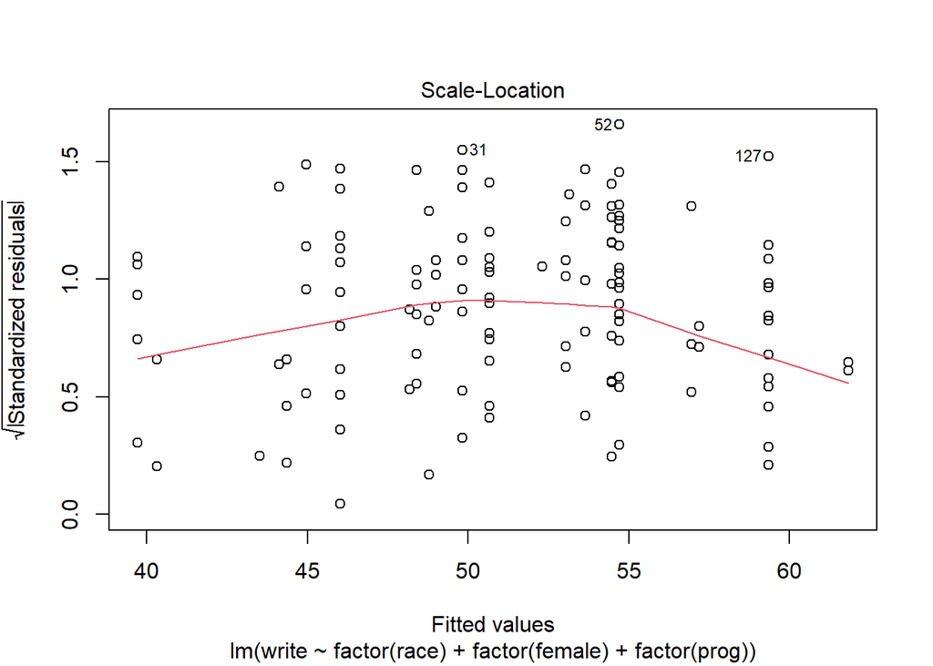

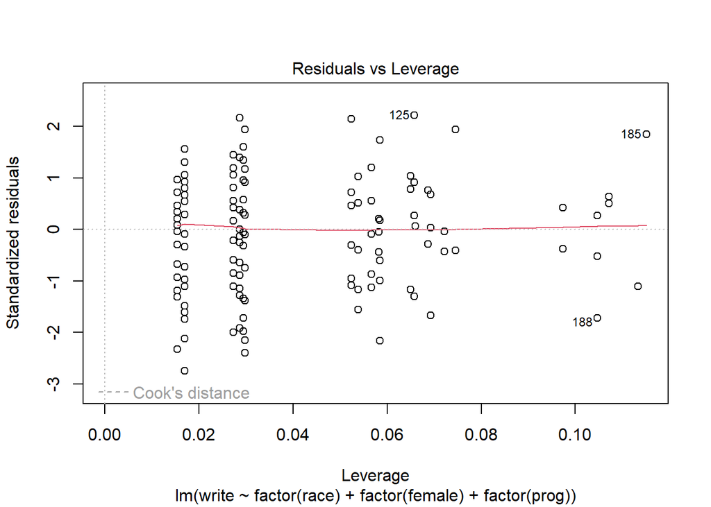

```r
plot(step.model)
```

```r
shapiro.test(residuals(step.model))
```

```
##
##  Shapiro-Wilk normality test
##
## data:  residuals(step.model)
## W = 0.98735, p-value = 0.07189
```

```r
step.modelb <- stepAIC(yhat_g, direction = "backward",
                       trace = FALSE)
summary(step.modelb)
```

```
##
## Call:
## lm(formula = write ~ factor(race) + factor(female) + factor(prog),
##     data = hsb2)
##
## Residuals:
##     Min      1Q  Median      3Q     Max
## -21.695  -5.346   0.102   5.654  17.029
##
## Coefficients:
##                 Estimate Std. Error t value Pr(>|t|)
## (Intercept)      43.5229     2.0437  21.296  < 2e-16 ***
## factor(race)2     8.7846     2.9410   2.987 0.003183 **
## factor(race)3     0.6051     2.4219   0.250 0.802961
## factor(race)4     6.3024     1.7646   3.572 0.000448 ***
## factor(female)1   4.6512     1.1389   4.084 6.49e-05 ***
## factor(prog)2     4.8694     1.4209   3.427 0.000746 ***
## factor(prog)3    -3.8085     1.6502  -2.308 0.022062 *
## ---
## Signif. codes:  0 '***' 0.001 '**' 0.01 '*' 0.05 '.' 0.1 ' ' 1
##
## Residual standard error: 7.954 on 193 degrees of freedom
## Multiple R-squared:  0.3171, Adjusted R-squared:  0.2958
## F-statistic: 14.93 on 6 and 193 DF,  p-value: 5.263e-14
```

```r
step.modelf <- stepAIC(yhat_g, direction = "forward",
                       trace = FALSE)
summary(step.modelf)
```

```
##
## Call:
## lm(formula = write ~ factor(race) + factor(female) + factor(ses) +
##     factor(schtyp) + factor(prog), data = hsb2)
##
## Residuals:
##      Min       1Q   Median       3Q      Max
## -22.6159  -4.6932   0.3381   5.4092  17.8269
##
## Coefficients:
##                 Estimate Std. Error t value Pr(>|t|)
## (Intercept)      42.8257     2.1935  19.524  < 2e-16 ***
## factor(race)2     8.5033     2.9529   2.880  0.00444 **
## factor(race)3     0.7350     2.4325   0.302  0.76286
## factor(race)4     5.8334     1.7984   3.244  0.00139 **
## factor(female)1   4.8436     1.1539   4.198 4.14e-05 ***
## factor(ses)2      0.8390     1.5211   0.552  0.58188
## factor(ses)3      2.6094     1.6926   1.542  0.12482
## factor(schtyp)2   0.3295     1.6033   0.206  0.83738
## factor(prog)2     4.3475     1.4596   2.978  0.00328 **
## factor(prog)3    -3.8049     1.6780  -2.267  0.02449 *
## ---
## Signif. codes:  0 '***' 0.001 '**' 0.01 '*' 0.05 '.' 0.1 ' ' 1
##
## Residual standard error: 7.959 on 190 degrees of freedom
## Multiple R-squared:  0.3269, Adjusted R-squared:  0.295
## F-statistic: 10.25 on 9 and 190 DF,  p-value: 7.825e-13
```

```r
AIC(step.model)
```

```
## [1] 1405.919
```

```r
AIC(step.modelb)
```

```
## [1] 1405.919
```

```r
AIC(step.modelf)
```

```
## [1] 1409.017
```